# Final cultural evolution figures

Beatriz Willink

2026-03-10

# Introduction

This document provides scripts for all figures included in the manuscript entitled “*Understanding cultural evolution in hummingbird leks through the fossilized birth-death process*” by Araya-Salas et al. (2023). Figures are plotted in the order they appear in the manuscript. Panels are plotted separately in some cases and arranged as a multipanel figures in others. Multipanel assembly, insertion of photos and illustrations, and minor esthetic changes were made in [Inkscape](https://inkscape.org/) v. 0.91.

Load required packages.

```r
require(ggplot2)
require(viridis)
require(tidyr)
require(kableExtra)
require(coda)
require(treeio)
require(ggtree)
require(gridExtra)
require(cowplot)
require(warbleR)
require(sf)
require(maptiles)
require(rnaturalearth)
require(ggspatial)
require(patchwork)
require(magick)
require(Rraven)

fig_cols <- viridis::mako(3, begin = 0.2, end = 0.8, direction = -1)
```

# Figure 1: historical sampling + map + bird picture

## Historical sampling pannel

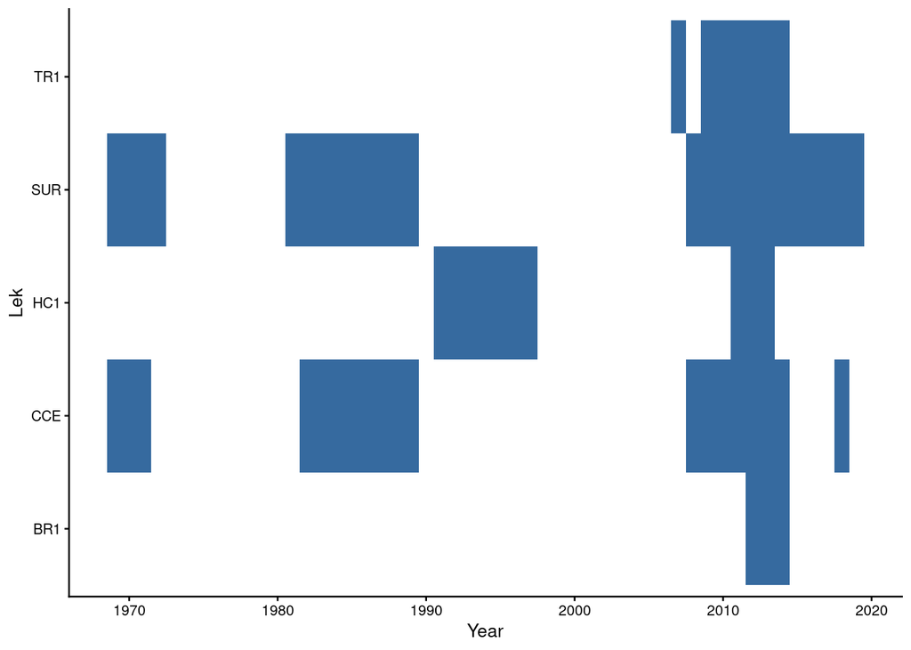

```r
fs <- read.csv("./data/processed/fossil_series.csv", header = T, sep = ",")

pal <- mako(10)

historic_gg <- ggplot(fs, aes(Year, Lek)) +
  geom_tile(colour = NA, aes(fill = Sampled)) +
  scale_fill_gradient(low = "white",
                      high = pal[5],
                      breaks = seq(0, 1, 1)) +
  theme_classic(base_size = 10) +
  theme(panel.grid.major.x = element_blank()) +
  theme(panel.grid.major.y  = element_blank()) +
  theme(legend.position = "none") +
  theme(plot.title = element_text(face = "bold")) +
  theme(plot.title.position = "plot")

historic_gg
```

## Map pannel

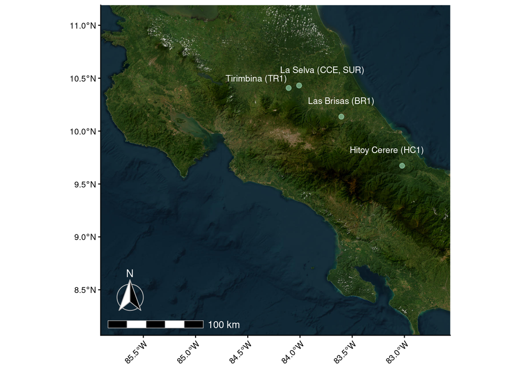

```r
# Get Costa Rica boundary
cr <- ne_countries(
  country = "Costa Rica",
  scale = "medium",
  returnclass = "sf"
)

# Your point in UTM (Zone 16N likely for Costa Rica)
point_utm <- st_as_sf(
  data.frame(x = 827522.5, y = 1154674.9),
  coords = c("x", "y"),
  crs = 32616
)

# Transform point to WGS84
point_wgs <- st_transform(point_utm, 4326)

coors <- data.frame(
  site = c(
    "\nTirimbina (TR1)                            ",
    "                    La Selva (CCE, SUR)",
    "Las Brisas (BR1)",
    "Hitoy Cerere (HC1)             "
  ),
  X = c(816606.7, 827536.0, 872224.4, 936731.3),
  Y = c(1151905.8, 1154611.2, 1122412.8, 1071719.4)
)

# Convert to sf (UTM zone 16N)
sites_utm <- st_as_sf(coors, coords = c("X", "Y"), crs = 32616)

# Transform to WGS84 to match satellite tiles
sites <- st_transform(sites_utm, 4326)

# Get satellite imagery
sat <- get_tiles(cr, provider = "Esri.WorldImagery", crop = TRUE, zoom = 9)

# Plot map with point
p <- ggplot() +
  layer_spatial(sat) +
  geom_sf(data = sites, color = viridis::mako(10, alpha = 0.6)[9], size = 2) +
  geom_sf_text(
    data = sites,
    aes(label = site),
    color = "white",
    size = 3,
    nudge_y = 0.15
  ) +
  annotation_north_arrow(
    location = "bl",
    which_north = "true",
    style = north_arrow_fancy_orienteering(
    fill = c("white", "black"),
    line_col = "gray",
    text_col = "white"
  ),
      pad_y = unit(0.7, "cm")) +
  coord_sf(expand = FALSE) +
  labs(x = NULL, y = NULL) +
    annotation_scale(
  location = "bl",
  width_hint = 0.3,
  text_cex = 0.8,
  line_width = 0.7,
   fill = c("white", "gray"),
    line_col = "gray",
    text_col = "white"
) + theme_classic(base_size = 10) +
    theme(
  axis.text.x = element_text(angle = 45, hjust = 1)
)
p
```

## Bird picture pannel

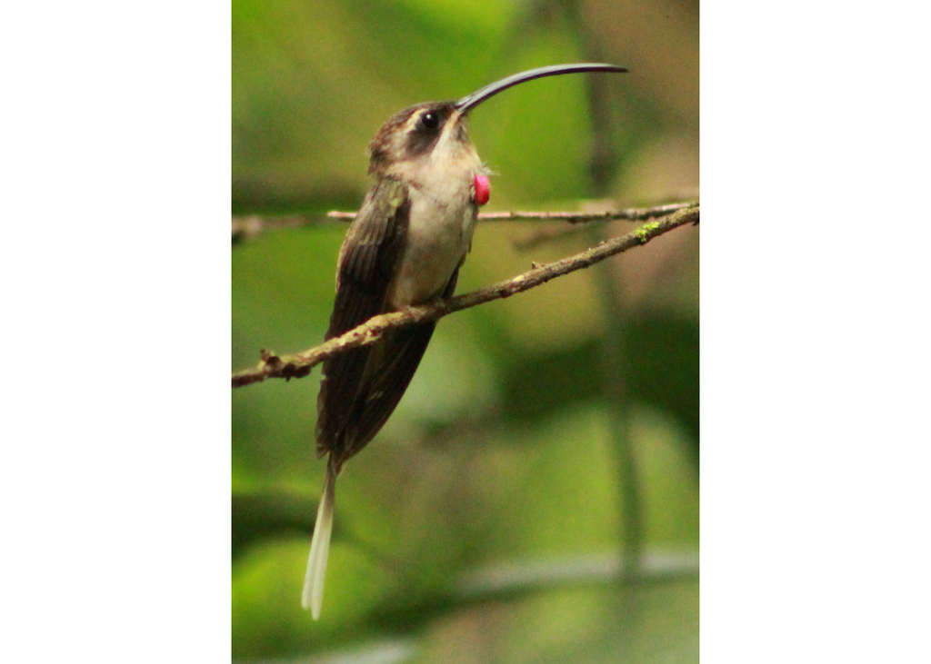

```r
# Read image
img <- image_read("./manuscript/Figures/cropped_lbh.jpeg")

# Convert image to ggplot panel
img_panel <- ggdraw() +
  draw_image(img) +
      scale_x_continuous(expand = c(0,0)) +
  scale_y_continuous(expand = c(0,0)) +
  theme_void() +
  theme(plot.margin = margin(0,0,0,0))
img_panel
```

## Combined multipannel figure

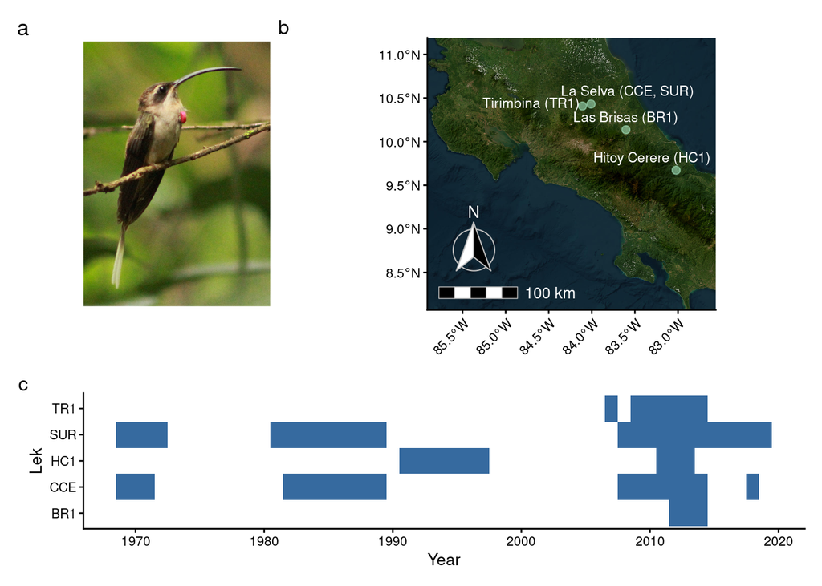

```r
# Combine panels
final_fig <- ((img_panel | p) + plot_layout(widths = c(1, 2.5))) /
              historic_gg +
              plot_layout(heights = c(1, 0.5)) +
              plot_annotation(tag_levels = "a")

final_fig
```

```r
# save figure
ggsave(
  "./manuscript/Figures/Fig1_V1.png",
  final_fig,
  width = 7,
  height = 6,
  dpi = 600
)
```

# Figure 2: Spectrograms of segmented songs

Measure repeatability of segment labels

Inter-observer reliability:

```r
# hans and last batch
obs1 <- imp_raven(
  files = c(
    "44kKz_songtype_segment_analysis_sep_2019 _ANALYZED_Hans.txt"
    # "96kKz_songtype_segment_analysis_sep_2019_ANALYZED_Hans.txt",
    # "last_batch_songtype_segment_analysis_sep_2019.txt"
  ),
  path = "/home/m/Dropbox/Projects/LBH cult-evo/Song_segment_analysis",
  all.data = TRUE,
  warbler.format = TRUE
)
```

```
## importing Raven files (step 0 of 0):
```

```r
obs1$segment_type <- tolower(obs1$segment_type)

# fix segment labels
obs1$segment_type[obs1$segment_type == "-pt"] <- "-p"
obs1$segment_type[obs1$segment_type == "-/p"] <- "/p"
obs1$segment_type[obs1$segment_type == "-st "] <- "-st"
obs1$segment_type[obs1$segment_type == "/pr"] <- "/p"
obs1$segment_type[obs1$segment_type == "/pt"] <- "/p"
obs1$segment_type[obs1$segment_type == "p"] <- "/p"
obs1$segment_type <- gsub("pt$", "p", obs1$segment_type)
obs1$segment_type[obs1$segment_type == "p"] <- "/p"
obs1$segment_type[grep("f", fixed = TRUE, obs1$segment_type)] <- "ft"
obs1$segment_type[grep("s", fixed = TRUE, obs1$segment_type)] <- "st"
obs1$segment_type[grep("m", fixed = TRUE, obs1$segment_type)] <- "mt"

#save extended selection table with finished segment song types
obs2 <- imp_raven(files = "Done_songtypes_segment_analysis_sep_2019.txt", path = "/home/m/Dropbox/Projects/LBH cult-evo/Song_segment_analysis/", all.data = TRUE, warbler.format = TRUE)


# fix segment labels
obs2$segment_type <- tolower(obs2$segment_type)
obs2$segment_type[obs2$segment_type == "-p-p"] <- "-p"
obs2$segment_type[obs2$segment_type == "-stst"] <- "st"
obs2$segment_type <- gsub("m$", "mt", obs2$segment_type)
obs2$segment_type <- gsub("f$", "ft", obs2$segment_type)
obs2$segment_type <- gsub("s$", "st", obs2$segment_type)
obs2$segment_type[grep("\\p", fixed = TRUE, obs2$segment_type)] <- "\\p"
obs2$segment_type[grep("//p", fixed = TRUE, obs2$segment_type)] <- "/p"
obs2$segment_type[grep("//f", fixed = TRUE, obs2$segment_type)] <- "f"
obs2$segment_type[grep("f", fixed = TRUE, obs2$segment_type)] <- "ft"
obs2$segment_type[grep("s", fixed = TRUE, obs2$segment_type)] <- "st"
obs2$segment_type[grep("m", fixed = TRUE, obs2$segment_type)] <- "mt"


obs1$lek.snr <- paste(obs1$lek, obs1$year, round(obs1$SNR, 5), sep = "-")
obs2$lek.snr <- paste(obs2$lek, obs2$year, round(obs2$SNR, 5), sep = "-")

shared <- intersect(obs1$lek.snr, obs2$lek.snr)

obs1 <- obs1[obs1$lek.snr %in% shared, ]
obs2 <- obs2[obs2$lek.snr %in% shared, ]

table(obs1$lek.snr)
```

```
##
## BR1-2013-13.78701 BR1-2013-14.65827 BR1-2013-21.92092 BR1-2013-22.38058
##                20                20                20                20
## BR1-2014--0.54754 BR1-2014--0.68812 BR1-2014-11.77491 BR1-2014-11.83109
##                20                20                20                20
## BR2-2012-14.49366  BR2-2012-16.1528 CCE-1971-13.08881 CCE-1971-16.02164
##                20                20                20                20
## CCE-1971-16.33328 CCL-1970-12.42529 CCL-1970-13.81039 CCL-1970-14.05837
##                20                20                20                20
## CCL-1970-14.64765 CCL-1970-17.35654 CCL-1970-17.40218 HC1-1991-20.03352
##                20                20                20                20
## HC1-1991-20.50928  HC1-1992-19.1231  HC1-1997-0.34104  HC1-1997-0.50208
##                20                20                20                20
##  HC1-1997-4.83409  HC1-1997-7.35104 HC1-2011-25.37361 HC1-2011-25.38653
##                20                20                20                20
## HC1-2011-26.03968 HC1-2011-26.10127 HC2-1992-17.41836 HC2-1992-18.65771
##                20                20                20                20
## HC2-2011-17.76585 HC2-2011-18.55155 HC2-2013-15.64273 HC2-2013-16.03929
##                20                20                20                20
## SAT-1989-14.82816  SAT-1989-16.7979  SAT-1989-9.17515  SAT-1989-9.22705
##                20                20                20                20
## SAT-2013-14.74256 SJA-2013-18.63048 SJA-2013-19.36559 SJA-2013-22.53777
##                20                20                20                20
## SJA-2013-22.69731  SJA-2013-23.3901 SJA-2013-23.42124 SJA-2014-19.51292
##                20                20                20                20
## SJA-2014-23.17233 SJA-2014-23.37137  SUR-2009-3.18433  SUR-2009-3.96688
##                20                20                20                20
## SUR-2011-20.20636 SUR-2011-21.43074 SUR-2011-23.07599 SUR-2011-23.65096
##                20                20                20                20
## SUR-2012-25.49949 SUR-2012-25.51343 TR1-2011-13.84175 TR1-2011-14.30603
##                20                20                20                20
## TR1-2011-19.40637 TR1-2011-20.03374 TR1-2013-20.30464  TR1-2014-13.0649
##                20                20                20                20
##  TR1-2014-13.3298  TR1-2014-19.4315 TR1-2014-19.55657 TR1-2014-20.79253
##                20                20                20                20
## TR1-2014-20.93223  TR2-2014-14.7309 TR2-2014-15.90022 TR2-2014-22.11857
##                20                20                20                20
## TR2-2014-22.42488
##                20
```

```r
table(obs2$lek.snr)
```

```
##
## BR1-2013-13.78701 BR1-2013-14.65827 BR1-2013-21.92092 BR1-2013-22.38058
##                20                20                20                20
## BR1-2014--0.54754 BR1-2014--0.68812 BR1-2014-11.77491 BR1-2014-11.83109
##                20                20                20                20
## BR2-2012-14.49366  BR2-2012-16.1528 CCE-1971-13.08881 CCE-1971-16.02164
##                20                20                20                20
## CCE-1971-16.33328 CCL-1970-12.42529 CCL-1970-13.81039 CCL-1970-14.05837
##                20                20                20                20
## CCL-1970-14.64765 CCL-1970-17.35654 CCL-1970-17.40218 HC1-1991-20.03352
##                20                20                20                20
## HC1-1991-20.50928  HC1-1992-19.1231  HC1-1997-0.34104  HC1-1997-0.50208
##                20                20                20                20
##  HC1-1997-4.83409  HC1-1997-7.35104 HC1-2011-25.37361 HC1-2011-25.38653
##                20                20                20                20
## HC1-2011-26.03968 HC1-2011-26.10127 HC2-1992-17.41836 HC2-1992-18.65771
##                20                20                20                20
## HC2-2011-17.76585 HC2-2011-18.55155 HC2-2013-15.64273 HC2-2013-16.03929
##                20                20                20                20
## SAT-1989-14.82816  SAT-1989-16.7979  SAT-1989-9.17515  SAT-1989-9.22705
##                20                20                20                20
## SAT-2013-14.74256 SJA-2013-18.63048 SJA-2013-19.36559 SJA-2013-22.53777
##                20                20                20                20
## SJA-2013-22.69731  SJA-2013-23.3901 SJA-2013-23.42124 SJA-2014-19.51292
##                20                20                20                20
## SJA-2014-23.17233 SJA-2014-23.37137  SUR-2009-3.18433  SUR-2009-3.96688
##                20                20                20                20
## SUR-2011-20.20636 SUR-2011-21.43074 SUR-2011-23.07599 SUR-2011-23.65096
##                20                20                20                20
## SUR-2012-25.49949 SUR-2012-25.51343 TR1-2011-13.84175 TR1-2011-14.30603
##                20                20                20                20
## TR1-2011-19.40637 TR1-2011-20.03374 TR1-2013-20.30464  TR1-2014-13.0649
##                20                20                20                20
##  TR1-2014-13.3298  TR1-2014-19.4315 TR1-2014-19.55657 TR1-2014-20.79253
##                20                20                20                20
## TR1-2014-20.93223  TR2-2014-14.7309 TR2-2014-15.90022 TR2-2014-22.11857
##                20                20                20                20
## TR2-2014-22.42488
##                20
```

```r
table(obs1$segment_type)
```

```
##
##  -p  /p \\p  ft  mt  st
## 193 267 175 467 178 180
```

```r
table(obs2$segment_type)
```

```
##
##  -p  /p \\p  ft  mt  st
## 269 201 177 376 307 130
```

```r
out <- lapply(shared, function(x){

    X <- obs1[obs1$lek.snr == x,]
    X <- X[order(X$start),]
    Y <- obs2[obs2$lek.snr == x,]
    Y <- Y[order(Y$start),]

    df <- data.frame(
      lek.song.type = X$lek.song.type[1],
      lek = X$lek[1],
      obs1 = X$segment_type,
      obs2 = Y$segment_type
    )
     if (nrow(df) == 20) {
        return(df) } else {
            return(NULL)
        }

    })


segments_2_observers <- do.call(rbind, out)

# copied from ~/Dropbox/Projects/LBH cult-evo/Song_segment_analysis/complete_segment_analysis_nov-2019.RDS
sgmt.est <- readRDS("./data/processed/complete_segment_analysis_nov-2019.RDS")


# measure repeatability
irr::kappa2(segments_2_observers[segments_2_observers$lek.song.type %in% sgmt.est$lek.song.type, c("obs1", "obs2")])
```

```
##  Cohen's Kappa for 2 Raters (Weights: unweighted)
##
##  Subjects = 1460
##    Raters = 2
##     Kappa = 0.507
##
##         z = 42.5
##   p-value = 0
```

```r
irr::kappa2(segments_2_observers[segments_2_observers$lek %in% c("BR1", "TR1", "CCE", "HC1", "SUR"), c("obs1", "obs2")])
```

```
##  Cohen's Kappa for 2 Raters (Weights: unweighted)
##
##  Subjects = 820
##    Raters = 2
##     Kappa = 0.575
##
##         z = 34.8
##   p-value = 0
```

Intra-observer reliability:

```r
# fix segments
sgmt.est$segment_type <- gsub("/ft", "-ft", sgmt.est$segment_type,  fixed = TRUE)
sgmt.est$segment_type <- gsub("\\ft", "-ft", sgmt.est$segment_type,  fixed = TRUE)
sgmt.est$segment_type <- gsub("/mt", "-mt", sgmt.est$segment_type,  fixed = TRUE)
sgmt.est$segment_type <- gsub("\\mt", "-mt", sgmt.est$segment_type,  fixed = TRUE)
sgmt.est$segment_type <- gsub("/mt", "-mt", sgmt.est$segment_type,  fixed = TRUE)


new.code <- data.frame(
  old = c("-st", "-ft", "\\p", "/p", "-p", "-mt"),
  new = c("s","f", "d", "u", "p", "m"),
  meaning = c("Slow trill", "Fast trill", "Downward\npure tone", "Upward\npure tone", "Flat\npure tone", "Medium\n-paced trill"), stringsAsFactors = FALSE
)

new.code <- new.code[match(c("s", "m", "f", "d", "p", "u"), new.code$new),]

sgmt.est$segment_type <- sapply(sgmt.est$segment_type, function(x)
  new.code$new[new.code$old == x]
  )


sgmt.est$lek.song.type.year <- paste(sgmt.est$lek.song.type, sgmt.est$year, sep = "-")


dat <- sgmt.est[sgmt.est$lek %in% c("BR1", "TR1", "CCE", "HC1", "SUR"), ]




out <- lapply(unique(sgmt.est), function(x){

    X <- sgmt.est[sgmt.est$lek.song.type.year == x,]

    if (nrow(X) > 20) {

        song.types <- unique(X$sound.files)
        rater1 <- X$segment_type[X$sound.files == song.types[1]]
        rater2 <- X$segment_type[X$sound.files == song.types[2]]

        df <- data.frame(rater1, rater2)

        return(df)
    } else {

        return(NULL)
        }
})

segment_replicates <- do.call(rbind, out)


# measure repeatability
irr::kappa2(segment_replicates)
```

```
##  Cohen's Kappa for 2 Raters (Weights: unweighted)
##
##  Subjects = 20
##    Raters = 2
##     Kappa = 0.922
##
##         z = 5.77
##   p-value = 8.13e-09
```

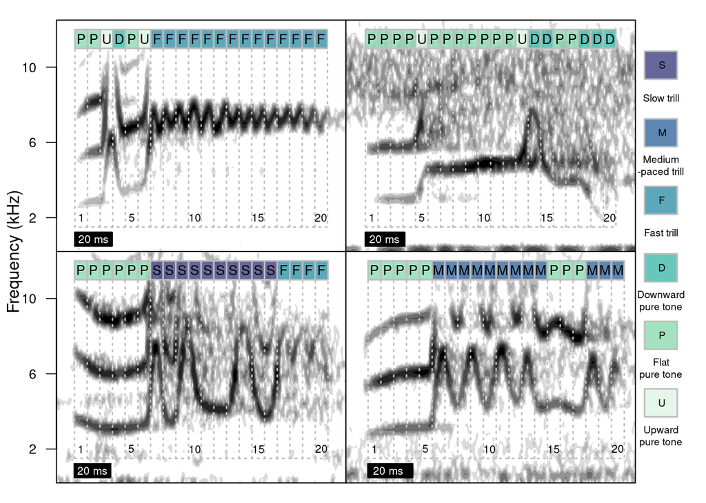

```r
# copied from /home/m/Dropbox/Projects/LBH cult-evo/data_for_beti/segments_by_song_type.csv
sgm_final <- read.csv("./data/processed/segments_by_song_type.csv")

sub.sgmt <- sgmt.est[sgmt.est$lek.song.type %in% sgm_final$song.type, ]

# sub.sgmt <- resample_est_waves(sub.sgmt, samp.rate = 44.1)
sub.sgmt$segment_type[sub.sgmt$sound.files == "CCL-G1-4"][15] <- "d"
sub.sgmt$end[sub.sgmt$sound.files == "SUR-J2-1"][20] <- sub.sgmt$end[sub.sgmt$sound.files == "SUR-J2-1"][20] + 0.005


wl <- 190
ovlp <- 99
collevels <- seq(-40, 0, 5)
pal <- reverse.gray.colors.2

 #if a matrix, then each row describes a screen with values for the left, right, bottom, and top of the screen (in that order) in NDC units, that is 0 at the lower left corner of the device surface, and 1 at the upper right corner.
sub.sgmt$segment_type[sub.sgmt$sound.files == "SUR-K1-1"][5:6] <- c("p", "u")

song_type <- c("SUR-K1-1", "CCL-G1-4", "SUR-E2-4", "SUR-J2-1")

# HC1-I1-4 HC1-C4-4 "SUR-D1-2"
tag_cols <- viridis::mako(6, alpha = 0.8, begin = 0.3)

# column breaks
left_margin <- 0.08
right_margin <- 0.1
cbs <- c(left_margin, ((1 - (left_margin + right_margin)) / 2) + left_margin, 1 - right_margin, 1)

m <- rbind(c(cbs[1], cbs[2], 0.5, 1), # top left
           c(cbs[2], cbs[3], 0.5, 1), # top right
           c(cbs[1], cbs[2], 0, 0.5), # bottom left
           c(cbs[2], cbs[3], 0, 0.5), # bottom right
           c(0, cbs[1], 0, 1), # freq label
           c(cbs[3], 1, 0, 1) # legend
           )

out <- split.screen(figs = m)
  #testing layout screens
      # for(i in 1:nrow(m))
      # {screen(i)
      #   par( mar = rep(0, 4))
      #   plot(0.5, xlim = c(0,1), ylim = c(0,1), type = "n", axes = FALSE, xlab = "", ylab = "", xaxt = "n", yaxt = "n")
      #   box()
      #   text(x = 0.5, y = 0.5, labels = i)
      # }
      # close.screen(all.screens = T)
      #
# freq label
screen(5)

par(mar = c(0, 0, 0, 0), bg = adjustcolor("white", alpha.f = 0), new = T, xpd = NA)
          plot(1, frame.plot = FALSE, xlim = c(0, 2), ylim = c(0, 2), type = "n", axes = FALSE, xlab = "", ylab = "", xaxt = "n", yaxt = "n")
          text(x = 0.5, y = 1, "Frequency (kHz)", srt = 90, cex = 1)


for (i in 1:length(song_type))
{

  screen(i)

  x_est <- sub.sgmt[which(sub.sgmt$sound.files == song_type[i]), ]

  wv <- read_sound_file(x_est, index = 1, from = 0, to = Inf)

  par(mar = c(if(i %in% c(1, 2)) 0 else 1,
            if(i %in% c(2, 4)) 0 else 0,
            if(i %in% c(1, 2)) 1 else 0,
            0))

  warbleR:::spectro_wrblr_int2(wv, wl = wl, ovlp = ovlp, palette = pal, collevels = collevels, flim = c(0.2, 12.5), grid = FALSE, axisX = FALSE, flab = NULL, tlab = NULL, axisY =  FALSE)

  if(!i %in% c(2, 4)) {

     axis(2, at = seq(2, 10, 4), labels = seq(2, 10, 4), las = 1, cex.axis = 0.8)
  }

  polygon(x = rep(c(min(x_est$start), max(x_est$end)), each = 2), y = c(1.5, 11, 11, 1.5), lty = 3, border = "gray", col = NULL, lwd = 1.5)

  line_pos <- seq(min(x_est$start), max(x_est$end), length.out = 21)


  # plot # 1
    text(x = line_pos[1] + (line_pos[2] - line_pos[1]) / 2, y = 2, labels = 1, cex = 0.65)

  for (e in 2:20){
    lines(x = rep(line_pos[e], 2), y = c(1.5, 11), lty = 3, lwd = 1.5, col = "gray")
    if (e %in% seq(5, 20, 5))
    text(x = line_pos[e] + (line_pos[2] - line_pos[1]) / 2, y = 2, labels = e, cex = 0.65)
    }

  # draw segment labels
merge_sgmts <- as.data.frame(x_est[ , c("start", "end", "segment_type")])
merge_sgmts$start <- line_pos[1:20]
merge_sgmts$end <- line_pos[2:21]

merge_sgmts <- merge_sgmts[merge_sgmts$segment_type != "delete", ]
merge_sgmts$col <- tag_cols[as.numeric(factor(merge_sgmts$segment_type, levels = c("s", "m", "f", "d", "p", "u")))]


for (e in 1:nrow(merge_sgmts)){
    polygon(x = c(merge_sgmts$start[e], merge_sgmts$end[e], merge_sgmts$end[e], merge_sgmts$start[e]), y = c(11, 11, 12, 12), lty = 1, lwd = 1.5, col = merge_sgmts$col[e], border = "gray")

  # add text label
  text(x = mean(c(merge_sgmts$start[e], merge_sgmts$end[e])), y = 11.5, labels = toupper(merge_sgmts$segment_type[e]), cex = 0.8)

  # time bar
  polygon(x = c(0.01, 0.03, 0.03, 0.01), y = c(0.5, 0.5, 1.2, 1.2), lty = 1, lwd = 1.5, col = "black")

  # add text label to time bar
  text(x = 0.015, y = 0.85, labels = "20 ms", cex = 0.65, adj = 0.2, col = "white")
}

}

screen(6)
# legend
par(mar = c(0, 0, 0, 0), oma = c(0, 0, 0, 0))
          plot(0.5, xlim = c(0, 1), ylim = c(0, 1), type = "n", axes = FALSE, xlab = "", ylab = "", xaxt = "n", yaxt = "n", frame.plot = FALSE)

    leg_pos <- seq(0.9, 0.03, length.out = length(tag_cols) + 1)

    for (y in 1:(length(tag_cols))){
    polygon(x = c(0.1, 0.6, 0.6, 0.1), y = c(leg_pos[y] - 0.03, leg_pos[y] - 0.03, leg_pos[y] + 0.03, leg_pos[y] + 0.03), lty = 1, lwd = 1.5, col = tag_cols[y], border = "gray")

  # add text label
      text(x = 0.35, y = leg_pos[y], labels = toupper(new.code$new[y]), cex = 0.6, adj = 0.35, col = "black")

  # add description
      text(x = 0.35, y = leg_pos[y] - 0.07, labels = new.code$meaning[y], cex = 0.6, adj = 0.5, col = "black")
    }
```

```r
invisible(close.screen(all.screens = TRUE))

# Then copy to PNG with your specifications
dev.copy(png, filename = "./manuscript/Figures/Fig2_V1.png",
         width = 200, height = 100, units = "mm", res = 300)
```

```r
dev.off()
```

# Figure 3: MAP trees

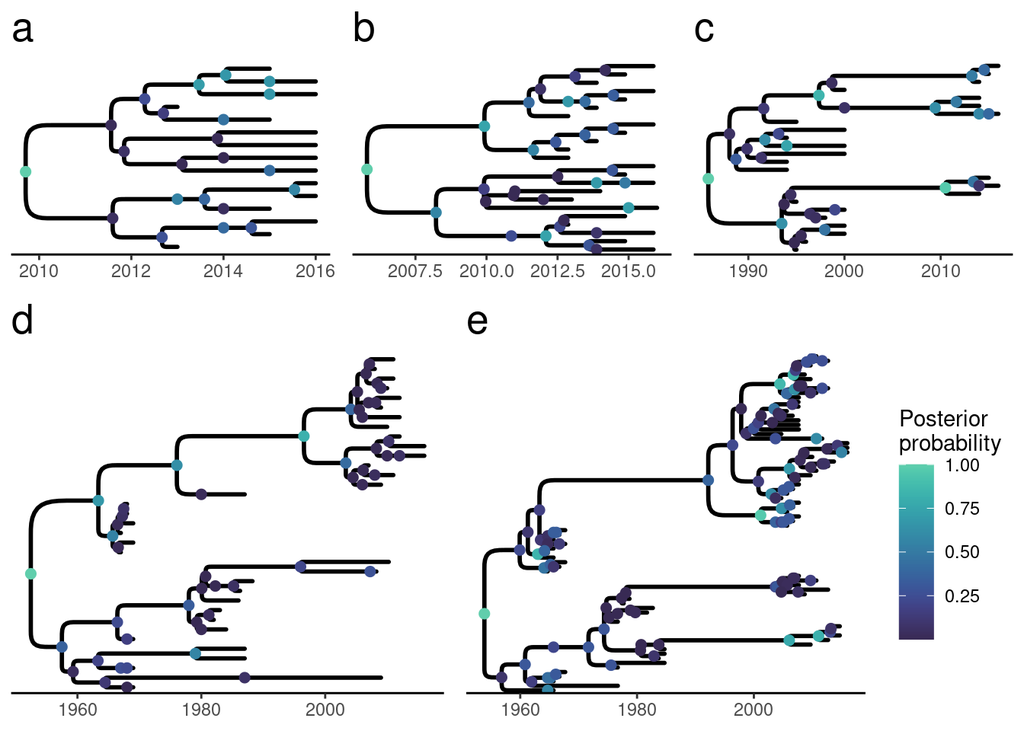

```r
tree_list <-
    list.files("./data/processed/map_trees", full.names = TRUE)

tree_data_list <- lapply(tree_list, read.beast)

names(tree_data_list) <- substr(basename(tree_list), 1, 3)

tips <- sapply(tree_data_list, Ntip)

tree_data_list <- tree_data_list[order(tips)]

options(ignore.negative.edge=TRUE)

phylos <- lapply(seq_along(tree_data_list), function(i) {
    tree <- tree_data_list[[i]]
    ggtree(tree, mrsd = "2016-01-01", color = "black", lwd = 1, layout = "roundrect") +
  geom_nodepoint(aes(colour = posterior), size = 2, show.legend = if (i == 5) TRUE else FALSE) +
  scale_color_viridis(option = "G", begin = 0.2, end = 0.8) +
  labs(title = letters[i], color = "Posterior\nprobability") +
  theme_tree2() +
            theme(
    plot.title = element_text(color = "black", size = 20)
  )
})


# make layout matrix
P_all <- grid.arrange(
  grobs = phylos,
  layout_matrix = rbind(c(1, 1, 1, 2, 2, 2, 3, 3, 3),
                        c(1, 1, 1, 2, 2, 2, 3, 3, 3),
                        c(4, 4, 4, 4, 5, 5, 5, 5, 5),
                        c(4, 4, 4, 4, 5, 5, 5, 5, 5),
                        c(4, 4, 4, 4, 5, 5, 5, 5, 5))
)
```

```r
cowplot::save_plot("./manuscript/Figures/Fig3_V1.png", P_all, device = "png", dpi = 300, units = "mm", base_width = 150, base_height = 100)
```

# Figure 4: Relative fit of clock models

Read first three ML reps

```r
# Read model names
m <- read.table(file = "./output/stdout/dataset.txt", header = F)
# Read three replicates of ML estimates under the stepping stone algorithm
ss.r1 <- read.table(file = "./output/stdout/SteppingStone.txt", header = F, sep = ",")
ss.r2 <- read.table(file = "./output/stdout/SteppingStoneR2.txt", header = F, sep = ",")
ss.r3 <- read.table(file = "./output/stdout/SteppingStoneR3.txt", header = F, sep = ",")

# missing models to NA and failed estimations to "Repeat"
n = 3 # currently three replicates

# make df
m.ml <- m
for (i in 1:n) {
  m.ml <- cbind(m.ml, eval(parse(text = paste0("ss.r", i))))
}
colnames(m.ml) <- c("Model", paste0("ss",c(1:n)))


for(i in 1:n) {
  m.ml[, i + 1] <- as.factor( m.ml[, i + 1])
  levels( m.ml[, i + 1]) <- c(levels( m.ml[, i + 1]),"Repeat")
  for (j in 1:nrow(m.ml)) {
        if (grepl(pattern = "This typically refers",
              x =  as.character(m.ml[j, i + 1]),
              fixed =  TRUE)) {
      m.ml[j, i + 1] <- "Repeat"
    }
    if (grepl(pattern = "Problem processing",
              x =  m.ml[j, i + 1],
              fixed =  TRUE)) {
      m.ml[j, i + 1] <- "Repeat"
    }
    if (grepl(pattern = "Could not open",
              x =  m.ml[j, i + 1],
              fixed =  TRUE)) {
      m.ml[j, i + 1] <- NA
    }
  }
  m.ml[,i+1] <- droplevels(m.ml[,i+1])
}
```

Read in repeats of failed approximations

```r
m.rep<- read.table(file = "./output/stdout/datasetRepeats.txt", header = F)

ss.rep <- read.table(file = "./output/stdout/SteppingStoneRepeat.txt", header = F, sep = ",")

m.ml.rep <-cbind(m.rep, ss.rep)
colnames(m.ml.rep) <- c("Model", "ss")

# match name format
m.ml.rep$Model <- gsub(pattern = "_", replacement = ".", x = m.ml.rep$Model)
m.ml.rep$Model <- gsub(pattern = ".global", replacement = "._global", x = m.ml.rep$Model)
m.ml.rep$Model <- gsub(pattern = ".Uexp", replacement = "._Uexp", x = m.ml.rep$Model)

#Replace repeat for ML value
m.ml$ss1 <- as.character(m.ml$ss1)
m.ml$ss2 <- as.character(m.ml$ss2)
m.ml$ss3 <- as.character(m.ml$ss3)

for (i in 1:nrow(m.ml)) {
  for (j in 1:nrow(m.ml.rep)) {
    if (m.ml$Model[i] == m.ml.rep$Model[j] & m.ml$ss1[i] == "Repeat") {
      m.ml$ss1[i] <-  m.ml.rep$ss[j]
    }
    if (m.ml$Model[i] == m.ml.rep$Model[j] & m.ml$ss2[i] == "Repeat") {
      m.ml$ss2[i] <-  m.ml.rep$ss[j]
    }
    if (m.ml$Model[i] == m.ml.rep$Model[j] & m.ml$ss3[i] == "Repeat") {
      m.ml$ss3[i] <-  m.ml.rep$ss[j]
    }
  }
}

m.ml$ss1 <- as.numeric(m.ml$ss1)
m.ml$ss2 <- as.numeric(m.ml$ss2)
m.ml$ss3 <- as.numeric(m.ml$ss3)
```

Make final table

```r
# remove "." from alignment name
m.ml$Model <- gsub(pattern = "all.equal", replacement = "allequal", x = m.ml$Model )

# split name into columns
m.ml <- m.ml %>% separate(Model, c("Lek", "Align", "Record", "Fossils", "Clock"))

# long to wide and rearrange
m.ml <-
  pivot_wider(
    data = m.ml,
    names_from = Clock,
    values_from =  paste0("ss", c(1:n))
  )

m.ml <-
  m.ml[, c(
    "Lek",
    "Align",
    "Record",
    "Fossils",
    paste0("ss", c(1:n), "_global"),
    paste0("ss", c(1:n), "_Uexp")
  )]

m.ml <- m.ml[complete.cases(m.ml[,5:10]),]

m.ml  %>%
  kbl(digits = 2) %>%
  kable_minimal()
```

| Lek | Align | Record | Fossils | ss1_global | ss2_global | ss3_global | ss1_Uexp | ss2_Uexp | ss3_Uexp |
| --- | --- | --- | --- | --- | --- | --- | --- | --- | --- |
| BR1 | allequal | new | all | -405.34 | -404.52 | -404.60 | -390.96 | -391.78 | -390.64 |
| BR1 | allequal | new | early | -349.61 | -348.98 | -349.60 | -342.83 | -342.93 | -343.02 |
| BR1 | optimal | new | all | -379.62 | -378.57 | -378.60 | -366.74 | -367.43 | -368.23 |
| BR1 | optimal | new | early | -324.76 | -324.87 | -324.78 | -321.02 | -320.28 | -320.61 |
| BR1 | prank | new | all | -418.26 | -417.81 | -418.25 | -394.68 | -396.11 | -396.11 |
| BR1 | prank | new | early | -351.84 | -351.36 | -351.41 | -342.55 | -342.39 | -342.44 |
| CCE | allequal | new | all | -324.61 | -325.49 | -325.08 | -312.37 | -312.50 | -312.22 |
| CCE | allequal | new | early | -266.92 | -267.15 | -267.35 | -264.04 | -264.07 | -263.58 |
| CCE | allequal | old | early | -608.17 | -607.44 | -607.68 | -603.43 | -603.85 | -604.66 |
| CCE | optimal | new | all | -350.98 | -349.84 | -350.73 | -332.77 | -332.78 | -333.25 |
| CCE | optimal | new | early | -281.17 | -282.26 | -282.05 | -276.80 | -276.09 | -276.53 |
| CCE | optimal | old | all | -724.78 | -726.17 | -723.44 | -707.00 | -709.33 | -707.08 |
| CCE | optimal | old | early | -606.93 | -606.94 | -606.49 | -598.11 | -598.65 | -597.93 |
| CCE | prank | new | all | -351.66 | -350.67 | -352.77 | -332.32 | -332.30 | -332.47 |
| CCE | prank | new | early | -281.46 | -281.52 | -281.59 | -273.54 | -274.03 | -273.50 |
| CCE | prank | old | early | -595.32 | -595.78 | -595.82 | -589.26 | -589.44 | -588.48 |
| HC1 | allequal | new | all | -155.36 | -155.06 | -155.38 | -151.08 | -151.37 | -151.29 |
| HC1 | allequal | new | early | -134.89 | -134.49 | -134.36 | -134.32 | -134.42 | -134.38 |
| HC1 | allequal | old | all | -625.01 | -626.13 | -623.97 | -614.41 | -614.13 | -612.69 |
| HC1 | allequal | old | early | -575.07 | -575.13 | -575.44 | -571.87 | -572.40 | -572.80 |
| HC1 | optimal | new | all | -159.56 | -159.14 | -159.49 | -155.30 | -155.58 | -155.50 |
| HC1 | optimal | new | early | -134.38 | -134.26 | -133.84 | -134.34 | -133.22 | -134.36 |
| HC1 | optimal | old | all | -632.06 | -633.10 | -632.33 | -613.40 | -613.77 | -613.78 |
| HC1 | optimal | old | early | -562.16 | -562.66 | -562.20 | -554.89 | -555.36 | -554.56 |
| HC1 | prank | new | all | -184.99 | -185.66 | -184.68 | -177.40 | -177.91 | -178.12 |
| HC1 | prank | new | early | -152.53 | -152.85 | -151.39 | -152.98 | -153.59 | -153.52 |
| HC1 | prank | old | all | -633.57 | -633.61 | -632.09 | -613.63 | -612.62 | -614.69 |
| SUR | allequal | new | all | -647.06 | -650.12 | -646.94 | -625.11 | -624.72 | -624.73 |
| SUR | allequal | new | early | -496.54 | -496.40 | -496.00 | -492.17 | -492.75 | -492.40 |
| SUR | allequal | old | all | -1021.34 | -1022.07 | -1017.82 | -988.91 | -990.99 | -990.81 |
| SUR | allequal | old | early | -789.07 | -789.17 | -789.22 | -776.97 | -777.75 | -778.36 |
| SUR | optimal | new | early | -494.65 | -494.83 | -494.41 | -485.39 | -485.50 | -485.53 |
| SUR | optimal | old | all | -1020.31 | -1020.67 | -1020.53 | -991.65 | -990.71 | -992.72 |
| SUR | optimal | old | early | -779.82 | -778.67 | -780.56 | -770.27 | -768.21 | -770.63 |
| SUR | prank | new | all | -716.85 | -715.73 | -715.86 | -675.18 | -675.44 | -676.77 |
| SUR | prank | new | early | -535.38 | -535.63 | -536.62 | -520.33 | -519.16 | -518.66 |
| SUR | prank | old | all | -1114.66 | -1111.25 | -1113.89 | -1056.28 | -1054.93 | -1057.88 |
| SUR | prank | old | early | -853.44 | -853.81 | -853.40 | -826.53 | -828.28 | -827.09 |
| TR1 | allequal | new | all | -455.42 | -455.69 | -456.99 | -436.56 | -437.69 | -437.53 |
| TR1 | allequal | new | early | -364.15 | -363.92 | -364.81 | -363.92 | -364.63 | -364.03 |
| TR1 | optimal | new | all | -472.88 | -474.03 | -473.13 | -451.86 | -454.53 | -455.17 |
| TR1 | optimal | new | early | -364.53 | -364.21 | -364.20 | -364.12 | -364.47 | -364.25 |
| TR1 | prank | new | all | -517.30 | -515.72 | -517.28 | -482.73 | -482.63 | -482.66 |
| TR1 | prank | new | early | -388.65 | -389.65 | -389.14 | -385.00 | -385.99 | -384.82 |

Plot results

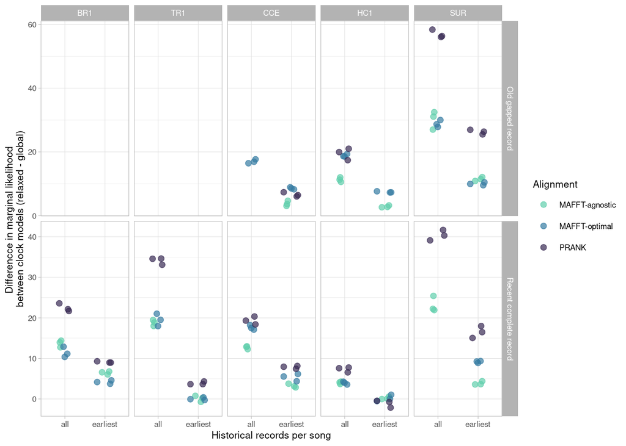

```r
# while missing data make numeric
m.ml$ss1_diff <- as.numeric(m.ml$ss1_Uexp) - as.numeric(m.ml$ss1_global)
m.ml$ss2_diff <- as.numeric(m.ml$ss2_Uexp) - as.numeric(m.ml$ss2_global)
m.ml$ss3_diff <- as.numeric(m.ml$ss3_Uexp) - as.numeric(m.ml$ss3_global)

# make long data frame
ml.long <- m.ml[,c(1:4,11:13)]
ml.long <-
  pivot_longer(data = ml.long,
               cols = paste0("ss", c(1:n), "_diff"),
               names_to = "run")

ml.long$Lek <-  factor(ml.long$Lek, levels=c('BR1','TR1','CCE','HC1', 'SUR'))
ml.long$Record <- factor(ml.long$Record, levels = c("old", "new"), ordered = T)

# new facet label names for fossil record
Record.labs <- c("Old gapped record",  "Recent complete record")
names(Record.labs) <- c( "old", "new")

# plot
ML.plot <-
  ggplot(data = ml.long, aes(
    x = Fossils,
    y = value,
    #shape = Record,
    colour = Align
    )) +
  geom_jitter(size = 2,
              alpha = 0.7,
              width = 0.2) +
  facet_grid(Record ~ Lek,
             scales = "free",
             labeller = labeller(Record = Record.labs)) +
  theme_light(base_size = 8) +
  labs(y = "Differencce in marginal likelihood \nbetween clock models (relaxed - global)", colour = "Alignment", x = "Historical records per song") +
  #scale_shape_discrete(guide = "none") +
  scale_colour_manual(
    values = fig_cols,
    labels = c("MAFFT-agnostic", "MAFFT-optimal", "PRANK")
  ) +
  scale_x_discrete(labels = c("all", "earliest"))

ML.plot
```

Export ML plot

```r
ggtree::ggsave(filename = "./manuscript/Figures/Fig4_V1.png", plot = ML.plot, device = "png", dpi = 600, units = "mm", width = 180, height = 100)
```

# Figs 5-7 and S3-S32 Absolute model fit

Read P3 results

```r
p3_output_files <- list.files(path = "./output/P3_Results/", recursive = TRUE, pattern = "effectsizes", full.names = TRUE)

p3_results_l <- lapply(p3_output_files, function(x){

  Y <- read.csv(file.path(x))
  Y$model <- sapply(strsplit(x, "Results/", fixed = TRUE), "[", 2)

  return(Y)
})

p3_results <- do.call(rbind, p3_results_l)

p3_results$model <- gsub("/results_", "", p3_results$model)

p3_results$Lek <- sapply(strsplit(p3_results$model, "_"), "[[", 1)
p3_results$Lek <- factor(p3_results$Lek, levels = c("BR1", "TR1", "CCE", "HC1", "SUR"))

p3_results$Align <- sapply(strsplit(p3_results$model, "_"), "[[", 2)
p3_results$Align <- factor(p3_results$Align, levels = c("all.equal", "optimal", "prank"), labels = c("MAFFT-agnostic", "MAFFT-optimal", "PRANK-TN93"))
Align.labs <- c("MAFFT-agnostic", "MAFFT-optimal", "PRANK-TN93")
names(Align.labs) <- c("all.equal", "optimal", "prank")

p3_results$Sampling <- sapply(strsplit(p3_results$model, "_"), "[[", 4)
p3_results$Sampling[p3_results$Sampling == "full.process"] <- "none"
p3_results$Sampling <- factor(p3_results$Sampling, levels = c("all", "early", "none"))
Sampling.labs <- c("all", "earliest", "none")
names(Sampling.labs) <- c("all", "early", "none")

p3_results$Record <- sapply(strsplit(p3_results$model, "_"), "[[", 3)
p3_results$Record <- factor(p3_results$Record, levels= c("old", "new", "no.fossils"), labels = c("Old gapped",  "Recent complete", "None"))
Record.labs <- c("Old gapped record",  "Recent complete record", "No historical record")
names(Record.labs) <- c( "old", "new", "no.fossils")
```

Plot posterior predictive effect sizes

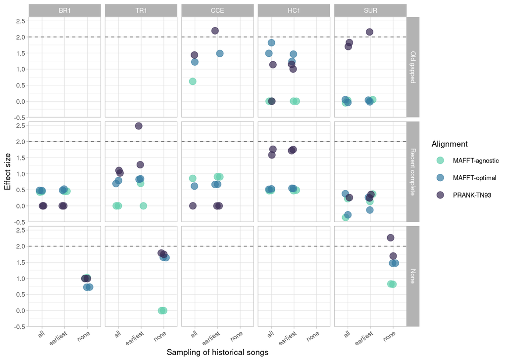

```r
ggs <- lapply(unique(p3_results$Statistic), function(x){
  ggplot(data = p3_results[p3_results$Statistic == x, ], aes(
    x = Sampling,
    y = Effect.Size,
    colour = Align,
  )) +
    geom_jitter(size = 3,
                alpha = 0.7,
                width = 0.12) +
    facet_grid(Record ~ Lek,
               scales = "fixed",
               labeller = labeller(Record = Record.labs)) +
    theme_light(base_size = 8) +
    labs(y = "Effect size", colour = "Alignment", x = "Sampling of historical songs") +
    scale_shape_discrete(guide = "none") +
    scale_colour_manual(
      values = fig_cols,
      labels = Align.labs
    ) +
    scale_x_discrete(labels = Sampling.labs) +
    geom_hline(yintercept = 2, lty = 2, col = "gray42") +
    theme(axis.text.x = element_text(angle = 35,  hjust = 1))
})

names(ggs) <- unique(p3_results$Statistic)

ggs$`Number Invariant Sites`
```

Plot posterior predictive p values

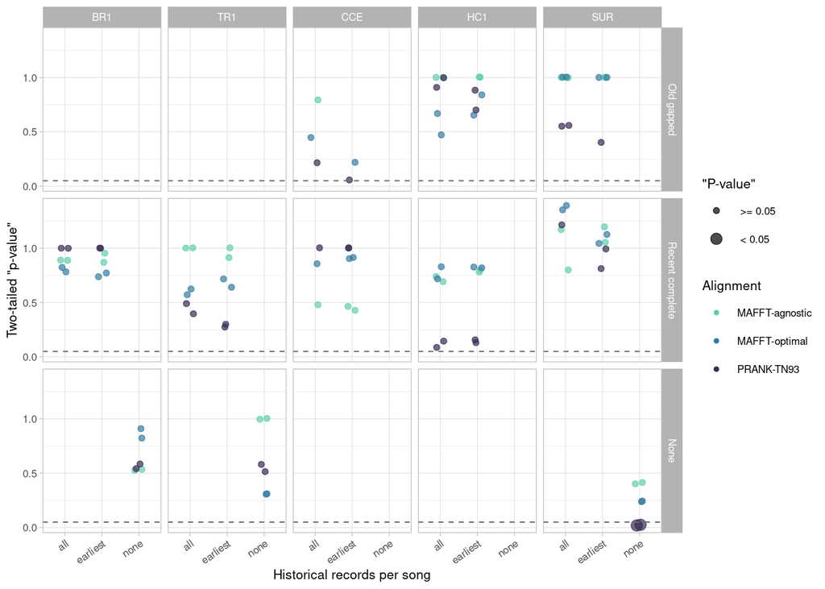

```r
p3_results$signif <- ifelse(p3_results$Two.tailed < 0.05, " < 0.05", " >= 0.05")
p3_results$Two.tailed.adj <- ifelse(p3_results$Two.tailed > 1, 1, p3_results$Two.tailed)
p3_results$signif <- factor(p3_results$signif, levels = c(" >= 0.05", " < 0.05"))
p3_results$alpha <- ifelse(p3_results$Two.tailed < 0.05, 1, 0.95)

ggs2 <- lapply(unique(p3_results$Statistic), function(x){
ggplot(data = p3_results[p3_results$Statistic == x, ], aes(
    x = Sampling,
    y = Two.tailed.adj,
    colour = Align,
    fill = Align,
    size = signif,
    alpha = signif,
  )) +
  geom_jitter(#size = 4,
              # alpha = 0.7,
              width = 0.12) +
  facet_grid(Record ~ Lek,
             scales = "fixed",
             labeller = labeller(Record = Record.labs)) +
  theme_light(base_size = 8) +
  labs(y = "Two-tailed \"p-value\"", colour = "Alignment", fill = "Alignment", x = "Historical records per song", size = "\"P-value\"", alpha = "\"P-value\"") +
  scale_size_manual(values = c(1.5, 3)) +
    scale_alpha_manual(values = c(0.7, 0.7)) +
    scale_colour_manual(
    values = fig_cols,
    labels = Align.labs
  ) +
    scale_fill_manual(
    values = viridis(3, direction = -1), #guide = FALSE,
    labels = Align.labs
  ) +
  scale_x_discrete(labels = Sampling.labs) +
    geom_hline(yintercept = 0.05, lty = 2, col = "gray42") +
    theme(axis.text.x = element_text(angle = 35,  hjust = 1))
})

names(ggs2) <- unique(p3_results$Statistic)

ggs2$`Number Invariant Sites`
```

Read posterior predictive simulations

```r
p3_empirical_files <- list.files(path = "./output/P3_Results/", recursive = TRUE, pattern = "empirical", full.names = TRUE)

p3_empirical_l <- lapply(p3_empirical_files, function(x){

  Y <- read.csv(file.path(x))
  Y$stat <- "mean"
  Y$data <- "empirical"
  Y$model <- sapply(strsplit(x, "Results//results_", fixed = TRUE), "[", 2)
  Y$model <- sapply(strsplit(Y$model, "/empirical", fixed = TRUE), "[", 1)


  return(Y)
})

p3_empirical <- do.call(rbind, p3_empirical_l)

p3_simulated_files <- list.files(path = "./output/P3_Results/", recursive = TRUE, pattern = "simulated", full.names = TRUE)

p3_simulated_l <- lapply(p3_simulated_files, function(x){

  Y <- read.csv(file.path(x))
  n <- nrow(Y)
  for (i in 1:length(colnames(Y))){
  Y[n+1,i] <- mean(Y[1:n,i])
  Y[n+2,i] <- HPDinterval(mcmc(Y[1:n,i]))[1]
  Y[n+3,i] <- HPDinterval(mcmc(Y[1:n,i]))[2]
  Y$stat[c((n+1):(n+3))]  <- c("mean", "lower", "upper")
  }

  Y$data <- "simulated"
  Y$model <- sapply(strsplit(x, "Results//results_", fixed = TRUE), "[", 2)
  Y$model <- sapply(strsplit(Y$model, "/simulated", fixed = TRUE), "[", 1)

  return(Y[c((n+1):(n+3)),])
})

p3_simulated <- do.call(rbind, p3_simulated_l)
rownames(p3_simulated) <- seq(1:nrow(p3_simulated))

p3_simulated <- rbind(p3_empirical, p3_simulated)

p3_simulated <- pivot_longer(p3_simulated, cols = c(1:16), names_to = "Statistic", values_to = "value")

p3_simulated <- pivot_wider(p3_simulated, names_from = "stat", values_from = "value")

p3_simulated$Lek <- sapply(strsplit(p3_simulated$model, "_"), "[[", 1)
p3_simulated$Lek <- factor(p3_simulated$Lek, levels = c("BR1", "TR1", "CCE", "HC1", "SUR"))

p3_simulated$Align <- sapply(strsplit(p3_simulated$model, "_"), "[[", 2)
p3_simulated$Align <- factor(p3_simulated$Align, levels = c("all.equal", "optimal", "prank"), labels = c("MAFFT-agnostic", "MAFFT-optimal", "PRANK-TN93"))

p3_simulated$Sampling <- sapply(strsplit(p3_simulated$model, "_"), "[[", 4)
p3_simulated$Sampling[p3_simulated$Sampling == "full.process"] <- "none"
p3_simulated$Sampling <- factor(p3_simulated$Sampling, levels = c("all", "early", "none"))
Sampling.labs <- c("all", "earliest", "none")
names(Sampling.labs) <- c("all", "early", "none")

p3_simulated$Record <- sapply(strsplit(p3_simulated$model, "_"), "[[", 3)
p3_simulated$Record <- factor(p3_simulated$Record, levels= c("old", "new", "no.fossils"), labels = c("Old gapped",  "Recent complete", "None"))

Record.labs <- c("Old gapped record",  "Recent complete record", "No historical record")
names(Record.labs) <- c( "old", "new", "no.fossils")
```

Plot simulated vs empirical data

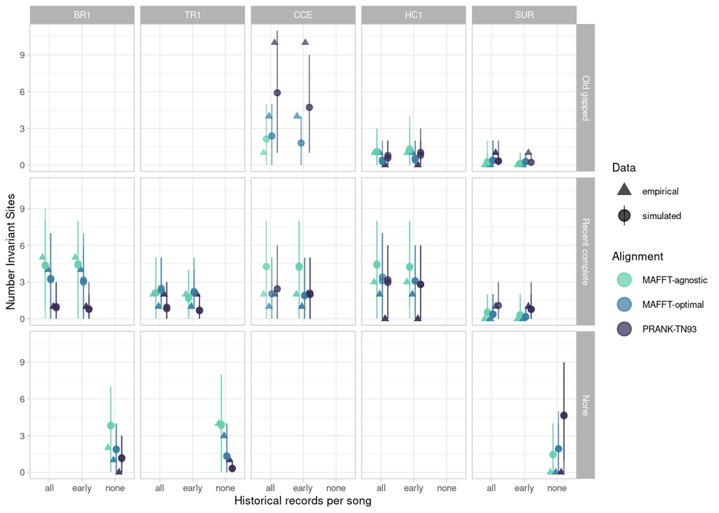

```r
ggs3 <- lapply(unique(p3_simulated$Statistic), function(x) {
  ggplot(
    data = p3_simulated[p3_simulated$Statistic == x, ],
    aes(
      x = Sampling,
      y = mean,
      colour = Align,
      fill = Align,
      shape = data
    )
  ) +
    geom_pointrange(
      aes(ymin = lower, ymax = upper),
      alpha = 0.7,
      position = position_dodge(width = 0.5)
    ) +
    facet_grid(
      Record ~ Lek,
      scales = "fixed",
      labeller = labeller(Record = Record.labs)
    ) +
    theme_light(base_size = 8) +
    labs(
      y = gsub("\\.", " ", x),
      colour = "Alignment",
      fill = "Alignment",
      x = "Historical records per song"
    ) +
    scale_shape_manual(
      values = c("triangle", "circle"),
      name = "Data",
      guide = guide_legend(
        override.aes = list(
          linetype = c(0, 1),
          size = c(0.8, 0.8),
          shape = c("triangle", "circle"),
          color = "black"
        )
      )
    ) +
    scale_colour_manual(
      values = fig_cols,
      labels = Align.labs,
       guide = guide_legend(
        override.aes = list(
            linetype = c(0, 0, 0),
            size = c(1, 1, 1),
          shape = c("circle", "circle", "circle")
          ))) +
    scale_fill_manual(
      values = viridis(3, direction = -1), guide = FALSE,
      labels = Align.labs
    )
})

names(ggs3) <- unique(p3_simulated$Statistic)

ggs3$Number.Invariant.Sites
```

Export main text figures 5-7

```r
figs <- list(ggs3$Number.Invariant.Sites, ggs3$Tajima.Pi, ggs3$Max.Pairwise.Difference)

for (i in 1:length(figs)) {
    ggtree::ggsave(
        filename = paste0(
            "./manuscript/Figures/Fig",
            i + 4,
            "_V1.png"),
            plot = figs[[i]],
            device = "png",
            dpi = 600,
            units = "mm",
            width = 180,
            height = 100
        )
}
```

Export supporting figures S3-S32

```r
sfigs <- list(ggs3[[1]],  ggs[[1]],  ggs2[[1]],
              ggs3[[13]], ggs[[13]], ggs2[[13]],
              ggs3[[3]],  ggs[[3]],  ggs2[[3]],
              ggs3[[7]],  ggs[[7]],  ggs2[[7]],
              ggs3[[11]], ggs[[11]], ggs2[[11]],
              ggs3[[5]],  ggs[[5]],  ggs2[[5]],
              ggs3[[9]],  ggs[[9]],  ggs2[[9]],
              ggs3[[14]], ggs[[14]], ggs2[[14]],
              ggs3[[15]], ggs[[15]], ggs2[[15]],
              ggs3[[16]], ggs[[16]], ggs2[[16]])

for (i in 1:length(sfigs)) {
    ggtree::ggsave(
        filename = paste0(
            "./manuscript/Figures/FigS",
            i + 2,
            "_V1.png"),
            plot = sfigs[[i]],
            device = "png",
            dpi = 600,
            units = "mm",
            width = 180,
            height = 100
        )
}
```

# Parameter sensitivity Figs 8-10 S33-S35

Prepare factor levels

```r
# directory of output files
out_fp <- "./output/most_recent_revbayes_models/"

# all the different factors and their levels
lek <- c("BR1", "CCE", "HC1", "SUR", "TR1")
aln <- c("all.equal", "optimal", "prank")
record <- c("old", "new", "no.fossils")
sampling <- c("all", "early")
clock <- c("global", "Uexp")

# colours and labels for figures below
aln_cols <- viridis(3,direction = -1)
aln_labs <- c("MAFFT-agnostic", "MAFFT-optimal", "PRANK-TN93")

record_cols <- viridis(3,direction = 1, begin = 0.7, end = 1)
record_labs <- c("old gapped", "recent complete", "no historical")

sampling_cols <-  viridis(2,direction = -1, begin = 0, end = 0.4)
sampling_labs <- c("all historical", "earliest record")

# what are the parameters of interest?
div_pars <- c("speciation_rate", "extinction_rate", "diversification", "age_extant", "origin_time")
new_pars <-  c("Speciation", "Extinction", "Diversification", "Crown_age", "Root_age")
```

Read data from PRANK alignment

```r
file.ls <- list.files(path=out_fp,pattern=paste0(glob2rx("*prank*all*Uexp_*"),"[0-9]{6}.log","|",glob2rx("*prank*full.process*Uexp_*"),"[0-9]{6}.log"))

dat_prank_record <- data.frame()
for (i in lek) {
  if (i == "SUR") {
    for (j in record) {
      tmp_file <-
        grep(pattern = paste(i, "prank", j , sep = "_"), file.ls)
      tmp_data <-
        read.table(paste0(out_fp, file.ls[tmp_file]), header = T)
      if (j == "no.fossils") {
        tmp_data$age_extant <- NA
      }
      tmp_data <- tmp_data[, c("Iteration", div_pars)]
      tmp_data$lek <- i
      tmp_data$record <- j
      dat_prank_record <- rbind(dat_prank_record, tmp_data)
    }
  } else {
    if (i == "BR1" | i == "TR1") {
      for (j in record[2:3]) {
        tmp_file <-
          grep(pattern = paste(i, "prank", j , sep = "_"), file.ls)
        tmp_data <-
          read.table(paste0(out_fp, file.ls[tmp_file]), header = T)
        if (j == "no.fossils") {
          tmp_data$age_extant <- NA
        }
        tmp_data <- tmp_data[, c("Iteration", div_pars)]
        tmp_data$lek <- i
        tmp_data$record <- j
        dat_prank_record <- rbind(dat_prank_record, tmp_data)
      }
    } else {
      for (j in record[1:2]) {
        tmp_file <-
          grep(pattern = paste(i, "prank", j , sep = "_"), file.ls)
        tmp_data <-
          read.table(paste0(out_fp, file.ls[tmp_file]), header = T)
        tmp_data <- tmp_data[, c("Iteration", div_pars)]
        tmp_data$lek <- i
        tmp_data$record <- j
        dat_prank_record <- rbind(dat_prank_record, tmp_data)
      }
    }
  }
}
```

Plot diversification parameters by historical record for PRANK data

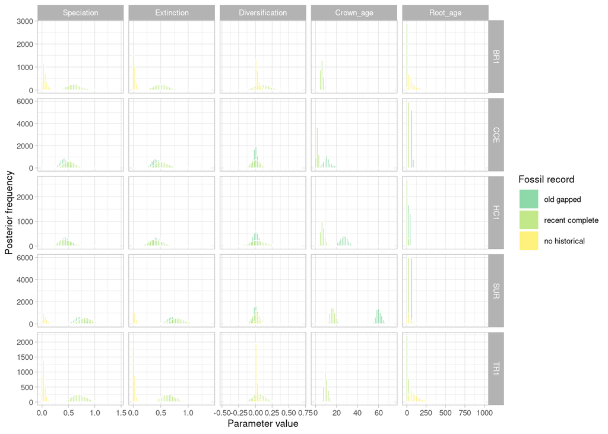

```r
colnames(dat_prank_record)[2:6] <- new_pars
plot_dat <- dat_prank_record[,c("Iteration", new_pars, "lek", "record")]

plot_dat <- pivot_longer(plot_dat, cols = all_of(new_pars), names_to = "par" )

plot_dat$par_s = factor(plot_dat$par, levels = new_pars)
plot_dat$record = factor(plot_dat$record, levels = c("old", "new", "no.fossils"))

p_div_h_record_prank <- ggplot(data = plot_dat, aes(x = value, fill = record)) +
  geom_histogram(position = "identity", bins = 50, colour = "white", alpha = 0.6) +
    facet_grid(lek ~ par_s, scales = "free") +
  theme_light(base_size = 8) +
  scale_fill_manual(values = record_cols, labels = record_labs) +
  labs(x = "Parameter value", y = "Posterior frequency", fill = "Fossil record")

p_div_h_record_prank
```

Export plot for Fig. 8

```r
ggtree::ggsave(
    filename = "./manuscript/Figures/Fig8_V1.png",
    plot = p_div_h_record_prank,
    device = "png",
    dpi = 600,
    units = "mm",
    width = 180,
    height = 100
)
```

Read data from MAFFT-optimal alignment

```r
file.ls <- list.files(path=out_fp,pattern=paste0(glob2rx("*optimal*all*Uexp_*"),"[0-9]{6}.log","|",glob2rx("*optimal*full.process*Uexp_*"),"[0-9]{6}.log"))

dat_optimal_record <- data.frame()
for (i in lek) {
  if (i == "SUR") {
    for (j in record) {
      tmp_file <-
        grep(pattern = paste(i, "optimal", j , sep = "_"), file.ls)
      tmp_data <-
        read.table(paste0(out_fp, file.ls[tmp_file]), header = T)
      if (j == "no.fossils") {
        tmp_data$age_extant <- NA
      }
      tmp_data <- tmp_data[, c("Iteration", div_pars)]
      tmp_data$lek <- i
      tmp_data$record <- j
      dat_optimal_record <- rbind(dat_optimal_record, tmp_data)
    }
  } else {
    if (i == "BR1" | i == "TR1") {
      for (j in record[2:3]) {
        tmp_file <-
          grep(pattern = paste(i, "optimal", j , sep = "_"), file.ls)
        tmp_data <-
          read.table(paste0(out_fp, file.ls[tmp_file]), header = T)
        if (j == "no.fossils") {
          tmp_data$age_extant <- NA
        }
        tmp_data <- tmp_data[, c("Iteration", div_pars)]
        tmp_data$lek <- i
        tmp_data$record <- j
        dat_optimal_record <- rbind(dat_optimal_record, tmp_data)
      }
    } else {
      for (j in record[1:2]) {
        tmp_file <-
          grep(pattern = paste(i, "optimal", j , sep = "_"), file.ls)
        tmp_data <-
          read.table(paste0(out_fp, file.ls[tmp_file]), header = T)
        tmp_data <- tmp_data[, c("Iteration", div_pars)]
        tmp_data$lek <- i
        tmp_data$record <- j
        dat_optimal_record <- rbind(dat_optimal_record, tmp_data)
      }
    }
  }
}
```

Plot diversification parameters by historical record for MAFFT-optimal data

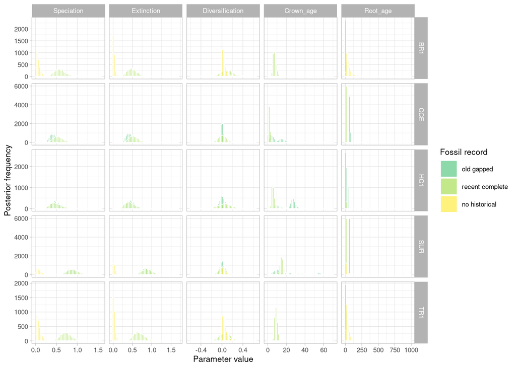

```r
colnames(dat_optimal_record)[2:6] <- new_pars
plot_dat <- dat_optimal_record[,c("Iteration", new_pars, "lek", "record")]

plot_dat <- pivot_longer(plot_dat, cols = all_of(new_pars), names_to = "par" )

plot_dat$par_s = factor(plot_dat$par, levels = new_pars)
plot_dat$record = factor(plot_dat$record, levels = c("old", "new", "no.fossils"))

p_div_h_record_optimal <- ggplot(data = plot_dat, aes(x = value, fill = record)) +
  geom_histogram(position = "identity", bins = 50, colour = "white", alpha = 0.6, size =0.05) +
  facet_grid(rows = vars(lek), cols = vars(par_s), scales = "free") +
  theme_light(base_size = 8) +
  scale_fill_manual(values = record_cols, labels = record_labs) +
  labs(x = "Parameter value", y = "Posterior frequency", fill = "Fossil record")

p_div_h_record_optimal
```

Read data from MAFFT-agnostic alignment

```r
file.ls <- list.files(path=out_fp,pattern=paste0(glob2rx("*all.equal*all*Uexp_*"),"[0-9]{6}.log","|",glob2rx("*all.equal*full.process*Uexp_*"),"[0-9]{6}.log"))

dat_agnostic_record <- data.frame()
for (i in lek) {
  if (i == "SUR") {
    for (j in record) {
      tmp_file <-
        grep(pattern = paste(i, "all.equal", j , sep = "_"), file.ls)
      tmp_data <-
        read.table(paste0(out_fp, file.ls[tmp_file]), header = T)
      if (j == "no.fossils") {
        tmp_data$age_extant <- NA
      }
      tmp_data <- tmp_data[, c("Iteration", div_pars)]
      tmp_data$lek <- i
      tmp_data$record <- j
      dat_agnostic_record <- rbind(dat_agnostic_record, tmp_data)
    }
  } else {
    if (i == "BR1" | i == "TR1") {
      for (j in record[2:3]) {
        tmp_file <-
          grep(pattern = paste(i, "all.equal", j , sep = "_"), file.ls)
        tmp_data <-
          read.table(paste0(out_fp, file.ls[tmp_file]), header = T)
        if (j == "no.fossils") {
          tmp_data$age_extant <- NA
        }
        tmp_data <- tmp_data[, c("Iteration", div_pars)]
        tmp_data$lek <- i
        tmp_data$record <- j
        dat_agnostic_record <- rbind(dat_agnostic_record, tmp_data)
      }
    } else {
      for (j in record[1:2]) {
        tmp_file <-
          grep(pattern = paste(i, "all.equal", j , sep = "_"), file.ls)
        tmp_data <-
          read.table(paste0(out_fp, file.ls[tmp_file]), header = T)
        tmp_data <- tmp_data[, c("Iteration", div_pars)]
        tmp_data$lek <- i
        tmp_data$record <- j
        dat_agnostic_record <- rbind(dat_agnostic_record, tmp_data)
      }
    }
  }
}
```

Plot diversification parameters by historical record for MAFFT-agnostic data

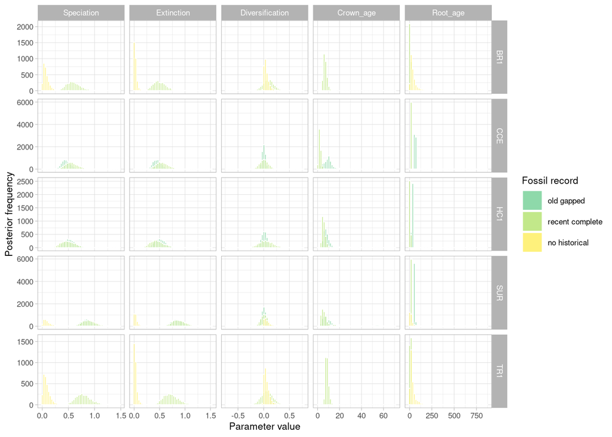

```r
colnames(dat_agnostic_record)[2:6] <- new_pars
plot_dat <- dat_agnostic_record[,c("Iteration", new_pars, "lek", "record")]

plot_dat <- pivot_longer(plot_dat, cols = all_of(new_pars), names_to = "par" )

plot_dat$par_s = factor(plot_dat$par, levels = new_pars)
plot_dat$record = factor(plot_dat$record, levels = c("old", "new", "no.fossils"))

p_div_h_record_agnostic <- ggplot(data = plot_dat, aes(x = value, fill = record)) +
  geom_histogram(position = "identity", bins = 50, colour = "white", alpha = 0.6, size =0.05) +
  facet_grid(rows = vars(lek), cols = vars(par_s), scales = "free") +
  theme_light(base_size = 8) +
  scale_fill_manual(values = record_cols, labels = record_labs) +
  labs(x = "Parameter value", y = "Posterior frequency", fill = "Fossil record")
p_div_h_record_agnostic
```

Export supporting figures S33-S35

```r
sfigs <- list(p_div_h_record_prank, p_div_h_record_optimal, p_div_h_record_agnostic)

for (i in 1:length(sfigs)) {
    ggtree::ggsave(
        filename = paste0(
            "./manuscript/Figures/FigS",
            i + 32,
            "_V1.png"),
            plot = sfigs[[i]],
            device = "png",
            dpi = 600,
            units = "mm",
            width = 180,
            height = 100
        )
}
```

Read data from all alignments and selected historical records

```r
file.ls <- list.files(path=out_fp,pattern=paste0(glob2rx("*all_*Uexp*"),"_[0-9]{6}.log"))

dat_com <- data.frame()
for (i in lek){
  if (i == "BR1" | i == "TR1" )
  for (j in aln) {
    tmp_file <- grep(pattern = paste(i,j,"new", sep = "_"), file.ls)
    tmp_data <- read.table(paste0(out_fp,file.ls[tmp_file]), header = T)
    tmp_data$lek <- i
    tmp_data$aln <- j
    br_rates <- grep("branch_rates.", colnames(tmp_data))
    tmp_data <- tmp_data[,-br_rates]
    dat_com <- rbind(dat_com, tmp_data)
  } else {
    for (j in aln) {
    tmp_file <- grep(pattern = paste(i,j,"old", sep = "_"), file.ls)
    tmp_data <- read.table(paste0(out_fp,file.ls[tmp_file]), header = T)
    tmp_data$lek <- i
    tmp_data$aln <- j
    br_rates <- grep("branch_rates.", colnames(tmp_data))
    tmp_data <- tmp_data[,-br_rates]
    dat_com <- rbind(dat_com, tmp_data)
    }
  }
}
```

Plot diversification parameters by alignment

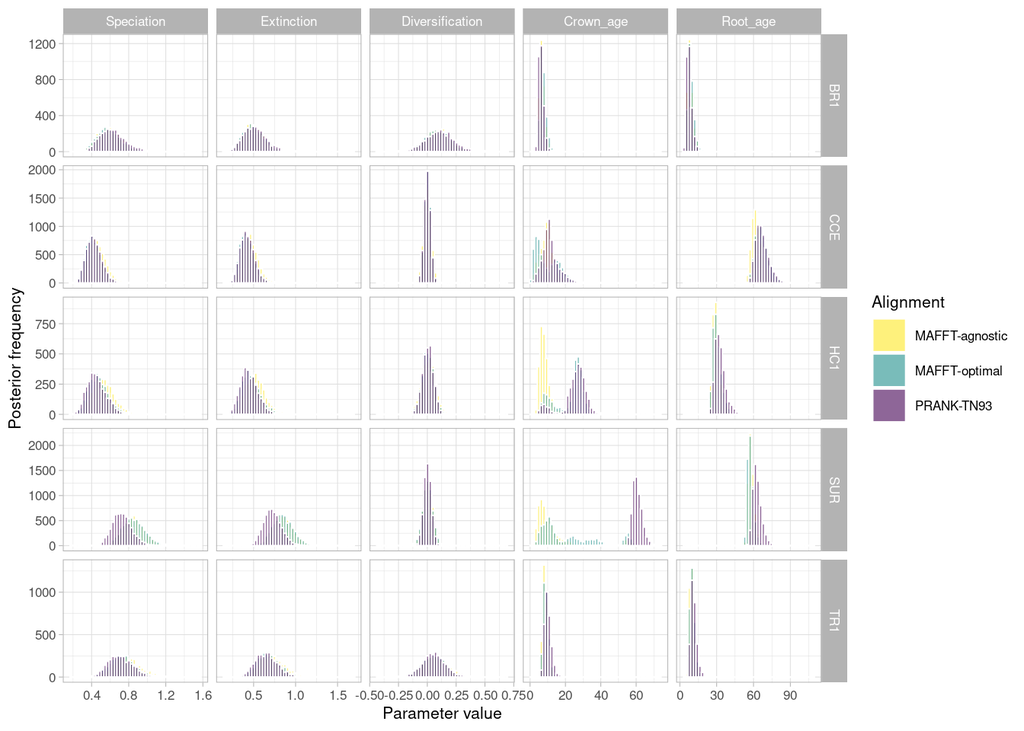

```r
# subset the data
plot_dat <- dat_com[,c("Iteration","lek", "aln", div_pars)]
colnames(plot_dat)[4:8] <- new_pars

# convert to long
plot_dat <- pivot_longer(plot_dat, cols = c(4:8), names_to = "par" )

# reorder parameters
plot_dat$par_s = factor(plot_dat$par, levels = new_pars)

# plot
p_div_h_aln <- ggplot(data = plot_dat, aes(x = value, fill = aln)) +
  geom_histogram(position = "identity", bins = 50, colour = "white", alpha = 0.6, size =0.05) +
  facet_grid(rows = vars(lek), cols = vars(par_s), scales = "free") +
  theme_light(base_size = 8) +
  scale_fill_manual(values = aln_cols, labels = aln_labs) +
  labs(x = "Parameter value", y = "Posterior frequency", fill = "Alignment")
p_div_h_aln
```

Export plot for Fig. 9

```r
ggtree::ggsave(
    filename = "./manuscript/Figures/Fig9_V1.png",
    plot = p_div_h_aln,
    device = "png",
    dpi = 600,
    units = "mm",
    width = 180,
    height = 100
)
```

Read record sampling data from PRANK alignment

```r
file.ls <- list.files(path=out_fp,pattern=paste0(glob2rx("*prank*Uexp_*"),"[0-9]{6}.log"))

dat_prank_sampling <- data.frame()
for (i in lek) {
  if (i == "BR1" | i == "TR1") {
    for (j in sampling) {
      tmp_file <-
        grep(pattern = paste(i, "prank", "new" , j , sep = "_"), file.ls)
      tmp_data <-
        read.table(paste0(out_fp, file.ls[tmp_file]), header = T)
      tmp_data <- tmp_data[, c("Iteration", div_pars)]
      tmp_data$lek <- i
      tmp_data$sampling <- j
      dat_prank_sampling <- rbind(dat_prank_sampling, tmp_data)
    }
  } else {
    for (j in sampling) {
      tmp_file <-
        grep(pattern = paste(i, "prank", "old", j , sep = "_"), file.ls)
      tmp_data <-
        read.table(paste0(out_fp, file.ls[tmp_file]), header = T)
      tmp_data <- tmp_data[, c("Iteration", div_pars)]
      tmp_data$lek <- i
      tmp_data$sampling <- j
      dat_prank_sampling <- rbind(dat_prank_sampling, tmp_data)
    }
  }
}
```

Plot diversification parameters by record sampling for PRANK data

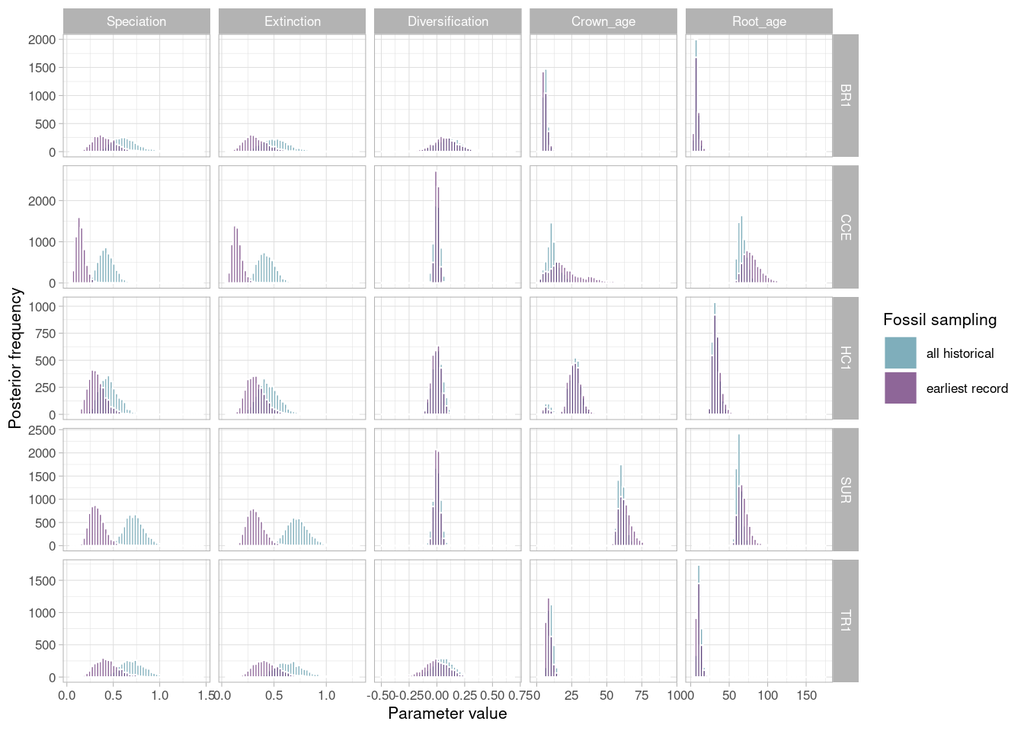

```r
colnames(dat_prank_sampling)[2:6] <- new_pars
plot_dat <- dat_prank_sampling[,c("Iteration", new_pars, "lek", "sampling")]

plot_dat <- pivot_longer(plot_dat, cols = all_of(new_pars), names_to = "par" )

plot_dat$par_s = factor(plot_dat$par, levels = new_pars)

p_div_h_sampling_prank <- ggplot(data = plot_dat, aes(x = value, fill = sampling)) +
  geom_histogram(position = "identity", bins = 50, colour = "white", alpha = 0.6, size =0.05) +
  facet_grid(rows = vars(lek), cols = vars(par_s), scales = "free") +
  theme_light(base_size = 8) +
  scale_fill_manual(values = sampling_cols, labels = sampling_labs) +
  labs(x = "Parameter value", y = "Posterior frequency", fill = "Fossil sampling")

p_div_h_sampling_prank
```

Export plot for Fig. 10

```r
ggtree::ggsave(
    filename = "./manuscript/Figures/Fig10_V1.png",
    plot = p_div_h_sampling_prank,
    device = "png",
    dpi = 600,
    units = "mm",
    width = 180,
    height = 100
)
```

Read record sampling data from MAFFT-optimal alignment

```r
file.ls <- list.files(path=out_fp,pattern=paste0(glob2rx("*optimal*Uexp_*"),"[0-9]{6}.log"))

dat_optimal_sampling <- data.frame()
for (i in lek) {
  if (i == "BR1" | i == "TR1") {
    for (j in sampling) {
      tmp_file <-
        grep(pattern = paste(i, "optimal", "new" , j , sep = "_"), file.ls)
      tmp_data <-
        read.table(paste0(out_fp, file.ls[tmp_file]), header = T)
      tmp_data <- tmp_data[, c("Iteration", div_pars)]
      tmp_data$lek <- i
      tmp_data$sampling <- j
      dat_optimal_sampling <- rbind(dat_optimal_sampling, tmp_data)
    }
  } else {
    for (j in sampling) {
      tmp_file <-
        grep(pattern = paste(i, "optimal", "old", j , sep = "_"), file.ls)
      tmp_data <-
        read.table(paste0(out_fp, file.ls[tmp_file]), header = T)
      tmp_data <- tmp_data[, c("Iteration", div_pars)]
      tmp_data$lek <- i
      tmp_data$sampling <- j
      dat_optimal_sampling <- rbind(dat_optimal_sampling, tmp_data)
    }
  }
}
```

Plot diversification parameters by record sampling for MAFFT-optimal data

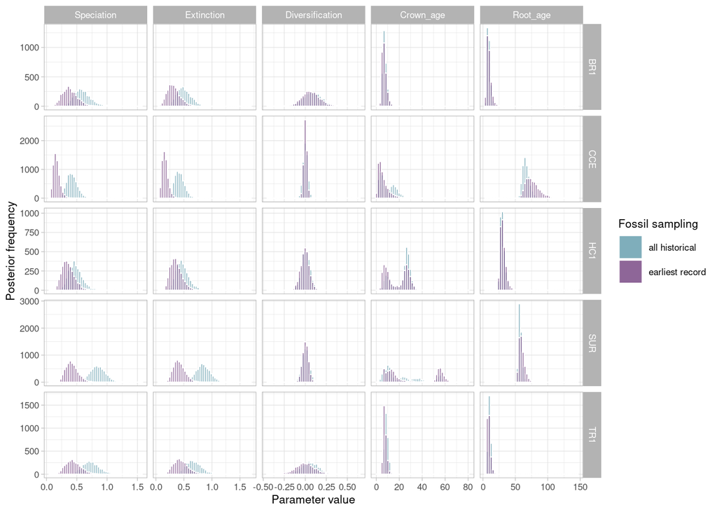

```r
colnames(dat_optimal_sampling)[2:6] <- new_pars
plot_dat <- dat_optimal_sampling[,c("Iteration", new_pars, "lek", "sampling")]

plot_dat <- pivot_longer(plot_dat, cols = all_of(new_pars), names_to = "par" )

plot_dat$par_s = factor(plot_dat$par, levels = new_pars)

p_div_h_sampling_optimal <- ggplot(data = plot_dat, aes(x = value, fill = sampling)) +
  geom_histogram(position = "identity", bins = 50, colour = "white", alpha = 0.6, size =0.05) +
  facet_grid(rows = vars(lek), cols = vars(par_s), scales = "free") +
  theme_light(base_size = 8) +
  scale_fill_manual(values = sampling_cols, labels = sampling_labs) +
  labs(x = "Parameter value", y = "Posterior frequency", fill = "Fossil sampling")

p_div_h_sampling_optimal
```

Read record sampling data from MAFFT-agnostic alignment

```r
file.ls <- list.files(path=out_fp,pattern=paste0(glob2rx("*all.equal*Uexp_*"),"[0-9]{6}.log"))

dat_agnostic_sampling <- data.frame()
for (i in lek) {
  if (i == "BR1" | i == "TR1") {
    for (j in sampling) {
      tmp_file <-
        grep(pattern = paste(i, "all.equal", "new" , j , sep = "_"), file.ls)
      tmp_data <-
        read.table(paste0(out_fp, file.ls[tmp_file]), header = T)
      tmp_data <- tmp_data[, c("Iteration", div_pars)]
      tmp_data$lek <- i
      tmp_data$sampling <- j
      dat_agnostic_sampling <- rbind(dat_agnostic_sampling, tmp_data)
    }
  } else {
    for (j in sampling) {
      tmp_file <-
        grep(pattern = paste(i, "all.equal", "old", j , sep = "_"), file.ls)
      tmp_data <-
        read.table(paste0(out_fp, file.ls[tmp_file]), header = T)
      tmp_data <- tmp_data[, c("Iteration", div_pars)]
      tmp_data$lek <- i
      tmp_data$sampling <- j
      dat_agnostic_sampling <- rbind(dat_agnostic_sampling, tmp_data)
    }
  }
}
```

Plot diversification parameters by record sampling for MAFFT-agnostic data

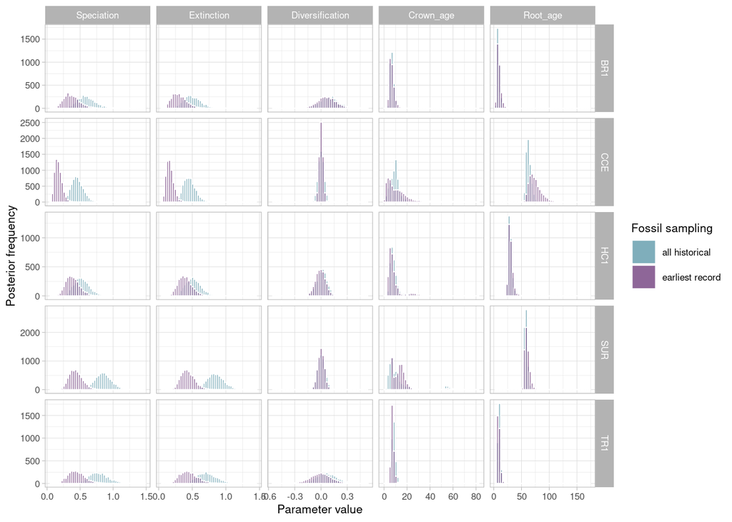

```r
colnames(dat_agnostic_sampling)[2:6] <- new_pars
plot_dat <- dat_agnostic_sampling[,c("Iteration", new_pars, "lek", "sampling")]

plot_dat <- pivot_longer(plot_dat, cols = all_of(new_pars), names_to = "par" )

plot_dat$par_s = factor(plot_dat$par, levels = new_pars)

p_div_h_sampling_agnostic <- ggplot(data = plot_dat, aes(x = value, fill = sampling)) +
  geom_histogram(position = "identity", bins = 50, colour = "white", alpha = 0.6, size =0.05) +
  facet_grid(rows = vars(lek), cols = vars(par_s), scales = "free") +
  theme_light(base_size = 8) +
  scale_fill_manual(values = sampling_cols, labels = sampling_labs) +
  labs(x = "Parameter value", y = "Posterior frequency", fill = "Fossil sampling")

p_div_h_sampling_agnostic
```

Export supporting figures S36-S38

```r
sfigs <- list(p_div_h_sampling_prank, p_div_h_sampling_optimal, p_div_h_sampling_agnostic)

for (i in 1:length(sfigs)) {
    ggtree::ggsave(
        filename = paste0(
            "./manuscript/Figures/FigS",
            i + 35,
            "_V1.png"),
            plot = sfigs[[i]],
            device = "png",
            dpi = 600,
            units = "mm",
            width = 180,
            height = 100
        )
}
```